# Lecture 16 - Law of large numbers

Joshua Loftus

#### Announcements

- Homework 5 due Thursday, but HW6 will be posted soon so don’t leave it off
- Mid-course survey also coming soon
- Today: `R` markdown, law of large numbers

#### Means of i.i.d. samples

- We’ve introduced some ideas about general parameter estimation, but we’ll now get back to means for a few lectures.
- In particular, we’ll be considering the mean $\bar X$ of **i.i.d. random variables** $X_1, \ldots, X_n$.
- Let $\mu = E[X_i]$, and $\sigma^2 = \text{Var}(X_i)$, so $E[\bar X] = \mu$ and $\text{Var}(\bar X) = \sigma^2/n$.
- Today we’ll discuss some mathematical results about what happens to $\bar X_n$ as $n$ increases.
- In real life, it is often the case that $n$ is not increasing–there is just one fixed sample, and no opportunity to collect more data.
- The results we see today still give us useful ways of thinking of $\bar X_n$, provided $n$ is “sufficiently large”
- History: Cardano noticed the phenomenon in 1500’s but didn’t prove anything about it, Jacob Bernoulli in 1713 (the Ber(p) case), extended as recently as 1929 by Khinchin
- We need a mathematical concept before we can state two version of the LLN

#### Limits of sequences

- A sequence of numbers indexed by $n$, denoted for example as $a_n$, is a list of numbers: $a_1, a_2, \ldots$ – which is *potentially infinite*
- e.g. Even numbers: $a_n = 2n$, so $a_1 = 2, a_2 = 4, a_3 = 6, \ldots$
- e.g. Reciprocals: $a_n = 1/n$, so $a_1 = 1, a_2 = 1/2, a_3 = 1/3, \ldots$
- e.g. $a_n = (2/3)^n$, so $a_1 = 2/3, a_2 = 4/9, a_3 = 8/27, \ldots$
- We say the sequence $a_n$ has a limit $a$, or in symbols:
  $$\lim_{n \to \infty} a_n = a \quad \text{ or } \quad a_n \to a \text{ as } n \to \infty$$
  if $a_n$ gets arbitrarily close to $a$ as $n$ gets larger.
- In math, this means that for any constant $c > 0$, no matter how small, it’s possible to find a large enough value $N$ so that $|a_n - a| < c$ for all $n \geq N$.
- e.g. $1/n \to 0$, why? For any $c > 0$, no matter how small, pick $N > 1/c$, so $1/N < c$. then for any $n \geq N$ we have $|1/n - 0| < c$.
- This is a technical definition, in a calculus or probability class there would be lots of exercises and results about limits. We won’t really use this definition, but you should know it exists. It is a mathematical foundation.
- **Notation**: for the rest of this lecture we’re going to emphasize that the sample mean depends on the sample size by giving it a subscript: $\bar X_n$.
- We’re now going to do a thought experiment: what happens to $\bar X_n$ if we keep increasing the sample size $n$?

#### Weak law of large numbers

- The weak law of large numbers says that, for any constant $c > 0$, no matter how small,
  $$P(|\bar X_n - \mu| > c) \to 0 \quad \text{as} \quad n \to \infty$$
- If you fix a small distance from the mean (a bit of “wiggle room”), the probability that $\bar X_n$ is outside that distance from the mean goes to 0 as $n$ becomes large enough
- Can use Chebyshev’s inequality to show this.

#### Strong law of large numbers

- The strong law of large numbers says
  $$\bar X_n \to \mu \quad \text{as} \quad n \to \infty$$
- Don’t need any fixed “wiggle room,” hence the names strong vs weak

#### How to think about laws of large numbers

- The main point is that the sample mean becomes closer and closer to its expected value as the sample size increases
- The sample mean is “random” – collect a different sample and you’ll get a different number
- But that randomness or variability is decreasing as $n$ becomes larger
- Remember the restaurant ratings example: each new observation is between 1 and 5 (stars)
- Suppose Restaurant $D$ has 9 ratings and an average of 3 stars.
- If the 10th rating is 1, the new average will be 2.8.
- If the 10th rating is 5, the new average will be 3.2
- Suppose Restaurant $E$ has 99 ratings and an average of 3 stars
- New rating can change it to 2.98-3.02, much smaller range.
- Starting with 999 ratings, the change from 1 new rating is so small it won’t show up in the first 2 decimal places.

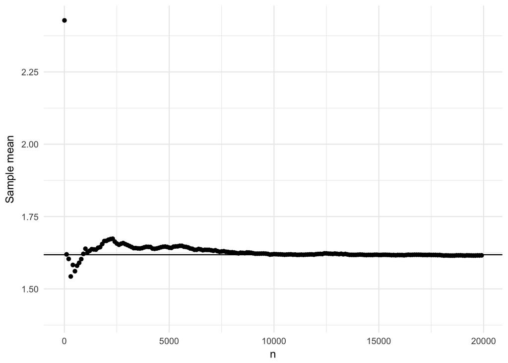

```r
# Largest sample size
max_n <- 20001
# True mean
true_mu <- (1 + sqrt(5))/2
# Generate a large sample
X <- rnorm(max_n, mean = true_mu, sd = 1)
# Make a list of sample sizes
n <- seq(from = 5, to = max_n, by = 100)
# Compute sample means for each sample size
Xbar_n <- sapply(n, function(first_n) mean(X[1:first_n]))
# Create a data frame for plotting
lln <- data.frame(n = n, Xbar_n = Xbar_n)
# Plot the sample sizes
ggplot(lln, aes(n, Xbar_n)) + geom_point() + geom_hline(yintercept = true_mu) +
  ylab("Sample mean") + theme_minimal() + ylim(c(min(1.4, min(Xbar_n)), max(2, max(Xbar_n))))
```

#### Square-root convergence

- At first the sample size increase makes a dramatic change, rapidly bringing the mean *somewhat* close to the truth.
- But then it takes longer and longer for the mean to keep getting closer to the truth by the same amount.
- Law of diminishing information.
- Remember from the sampling distribution: $\text{Var}(\bar X) = \sigma^2/n$.
- Hence, $\text{SD}(\bar X) = \sigma/\sqrt{n}$ – the dispersion decreases like 1 over the *square root* of the sample size.
- This is also referred to as a *square root convergence rate*.
- **Very important** rule of thumb to keep in mind, useful for interpreting data in real life.

#### “In the long run we are all dead” - Keynes

- Several warnings about misuse of the laws of large numbers…
- **First**, remember: it applies *in the long run*, it does *not* suggest that anything has to happen in the short run to make the sample mean move toward the true mean.
- If I toss a fair coin 10 times and it lands on heads all 10 times, the law of large numbers does *not* imply that the next toss should be a tails! This error is called the [Gambler’s fallacy](https://en.wikipedia.org/wiki/Gambler%27s_fallacy) because it is a common form of wishful thinking for gamblers to believe, if they have lost several games, that they are “due” to have a win soon.
- **Second**, it is possible to break the laws of large numbers if the random variables themselves are so dispersed that they *don’t have an expected value*.
- These are sometimes called “heavy-tailed” distributions. e.g. Cauchy distribution.

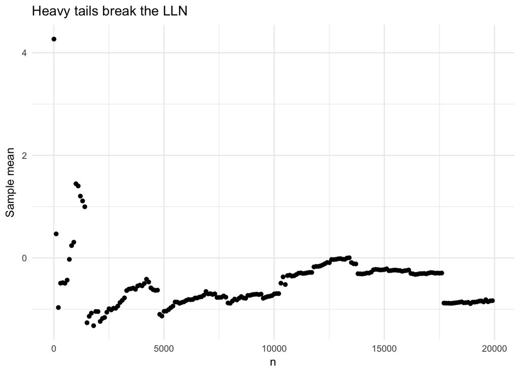

```r
set.seed(43)
X <- rcauchy(max_n)
Xbar_n <- sapply(n, function(first_n) mean(X[1:first_n]))
lln <- data.frame(n = n, Xbar_n = Xbar_n)
ggplot(lln, aes(n, Xbar_n)) + geom_point() + ylab("Sample mean") + theme_minimal() +
  ylim(c(min(1.4, min(Xbar_n)), max(2, max(Xbar_n)))) + ggtitle("Heavy tails break the LLN")
```

#### R markdown lab

- Download the `LLNlab.Rmd` file from the course page and open it in Rstudio.